# Rentabilidad de grandes eventos deportivos en el contexto de los paÃses BRICS

Rodrigo Minguito Linaje

4 de Enero de 2019

[1] “

## HDI

" [1] “

### Comparación con un año antes

"

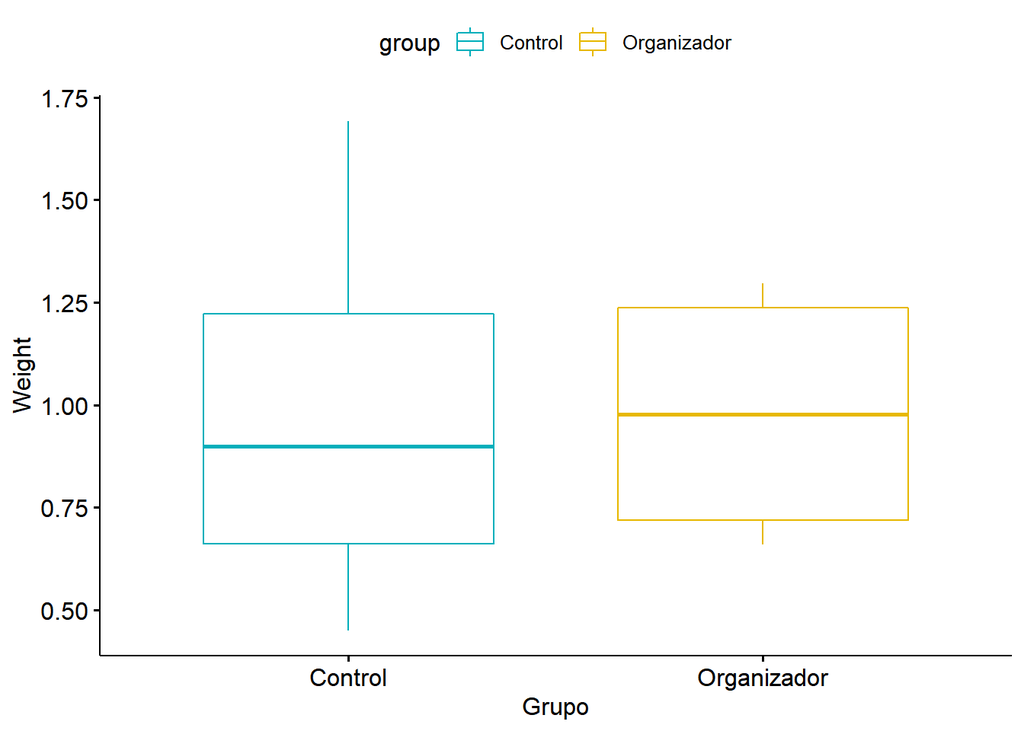

[1] “  
p-valor para un año antes 0.772829992684449” [1] “

### Comparación con un año después

"

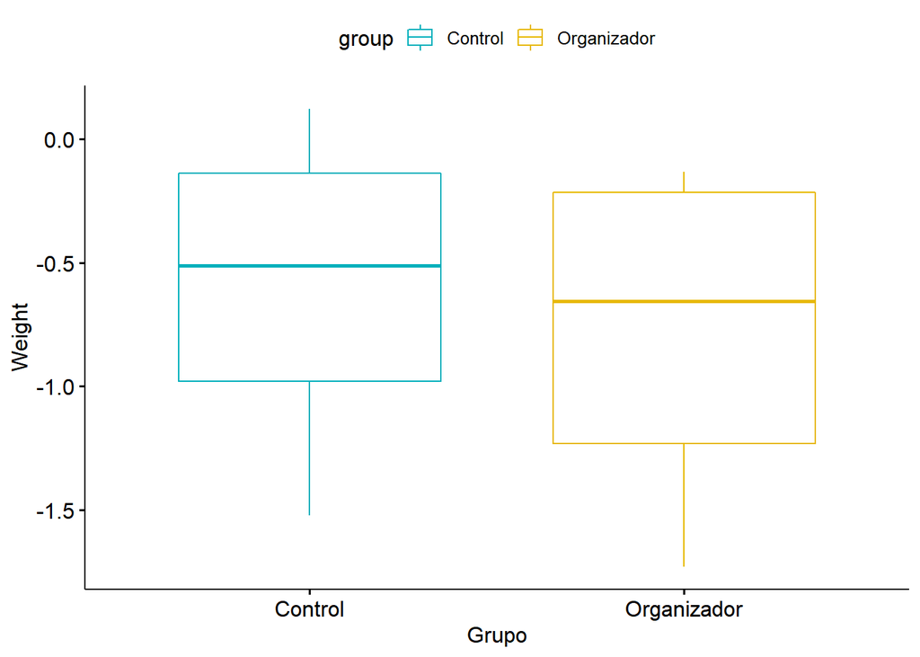

[1] “  
p-valor para un año después 0.563702861650774” [1] “

### Comparación con dos años después

"

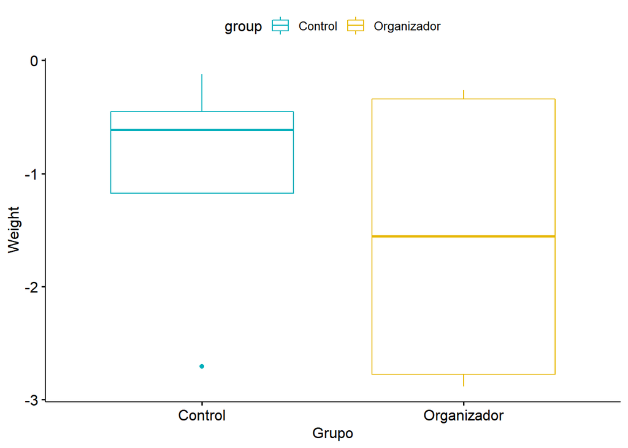

[1] “  
p-valor para dos años después 0.563702861650774” [1] “

## GPeaceIndex

" [1] “

### Comparación con un año antes

"

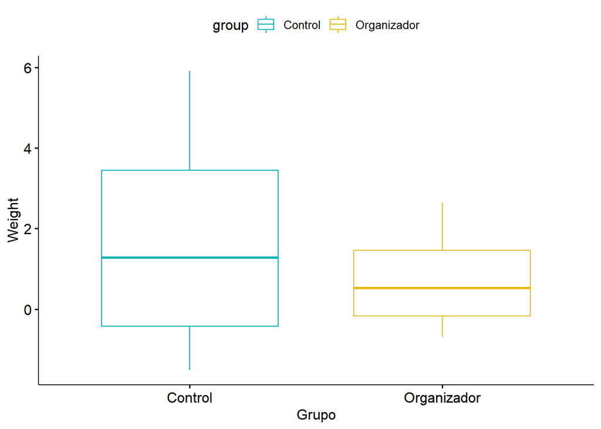

[1] “  
p-valor para un año antes 1” [1] “

### Comparación con un año después

"

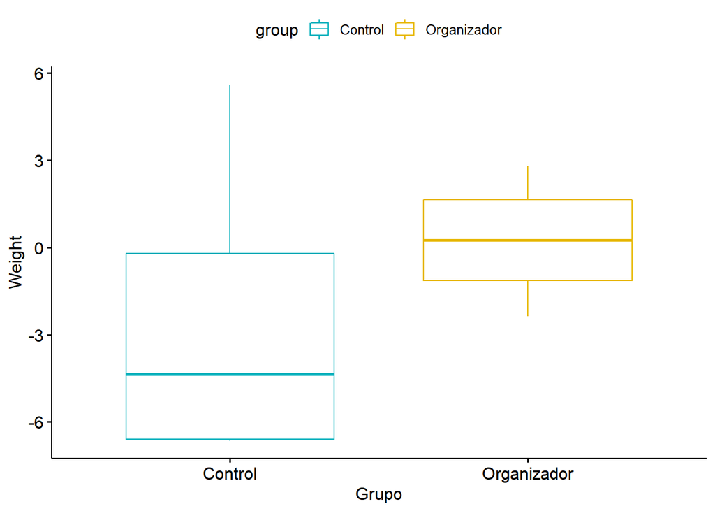

[1] “  
p-valor para un año después 0.386476230771233” [1] “

### Comparación con dos años después

"

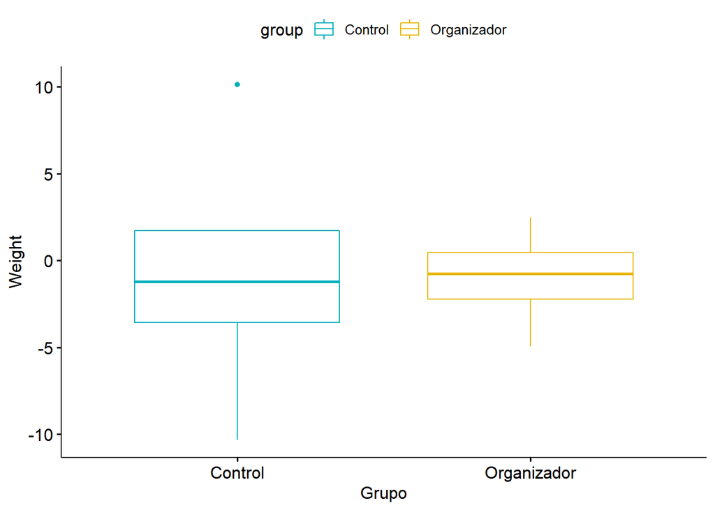

[1] “  
p-valor para dos años después 1” [1] “

## Inversion extranjera directa, entrada neta de capital (% del PIB)

" [1] “

### Comparación con un año antes

"

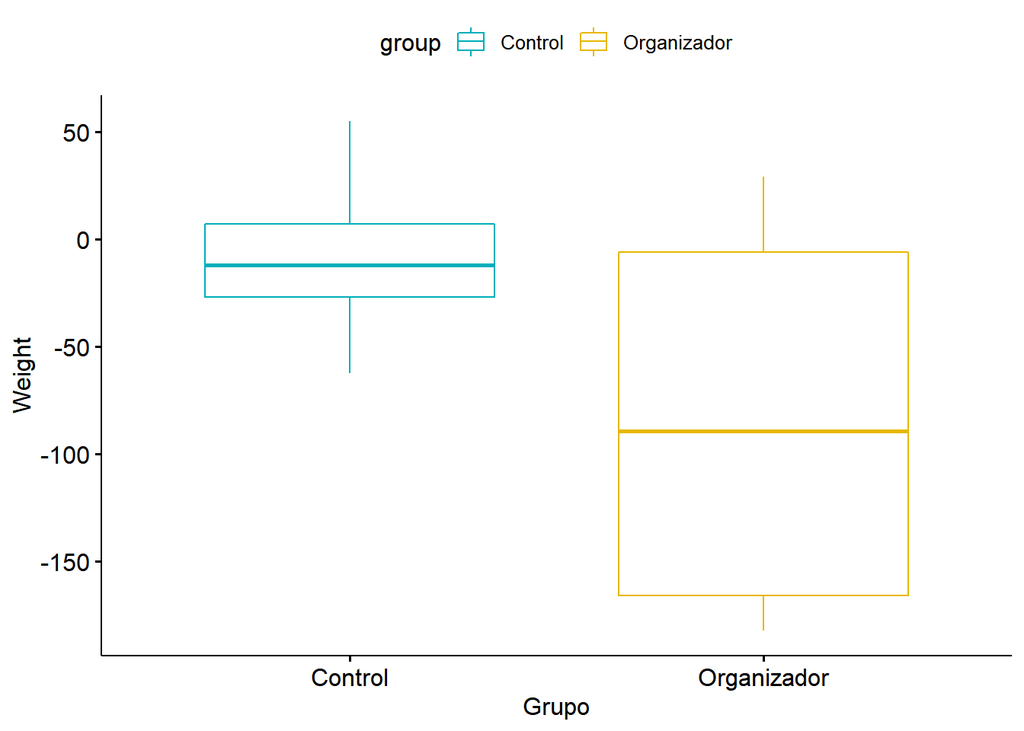

[1] “  
p-valor para un año antes 0.248213078989924” [1] “

### Comparación con un año después

"

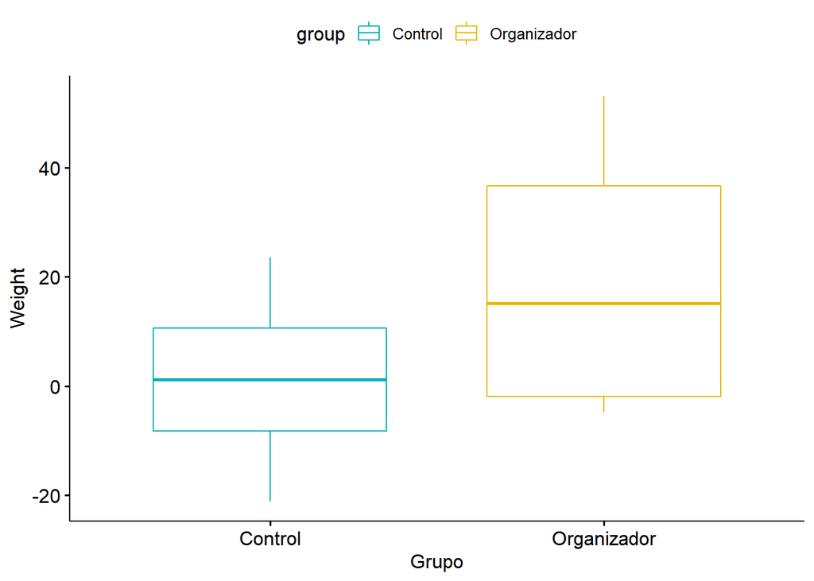

[1] “  
p-valor para un año después 0.386476230771233” [1] “

### Comparación con dos años después

"

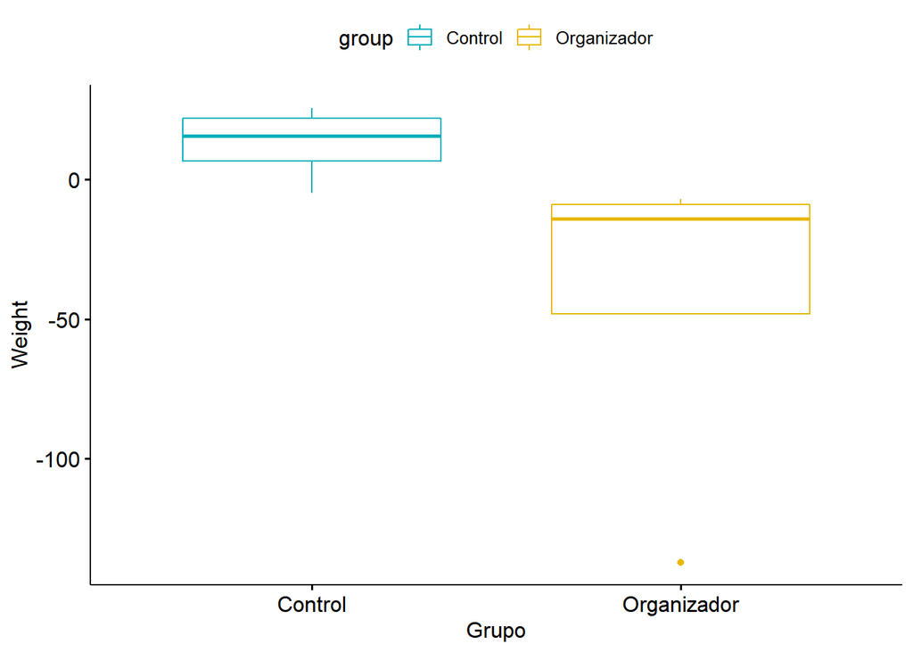

[1] “  
p-valor para dos años después 0.020921335337794” [1] “

## Acceso a tecnologias y combustibles limpios para cocinar (% de la poblacion)

" [1] “

### Comparación con un año antes

"

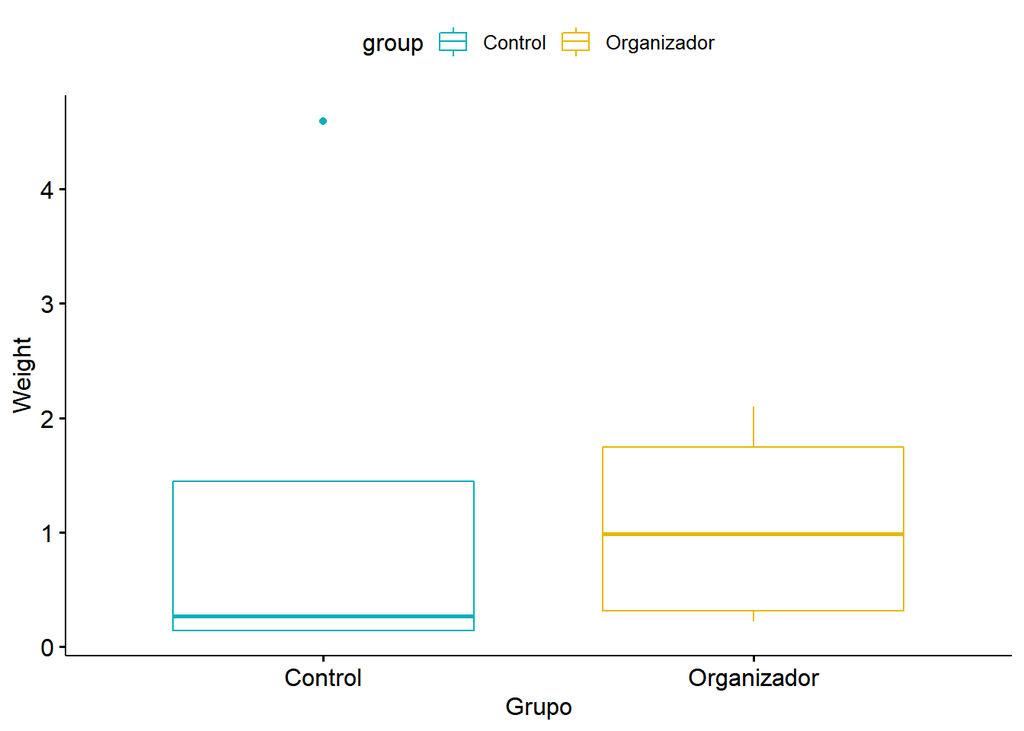

[1] “  
p-valor para un año antes 0.563702861650774” [1] “

### Comparación con un año después

"

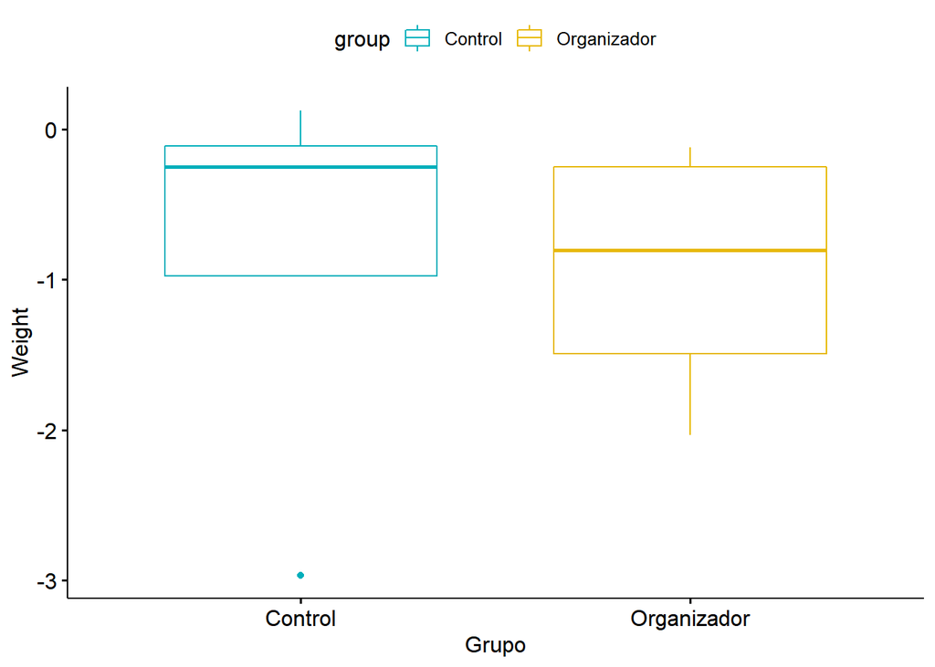

[1] “  
p-valor para un año después 0.772829992684449” [1] “

### Comparación con dos años después

"

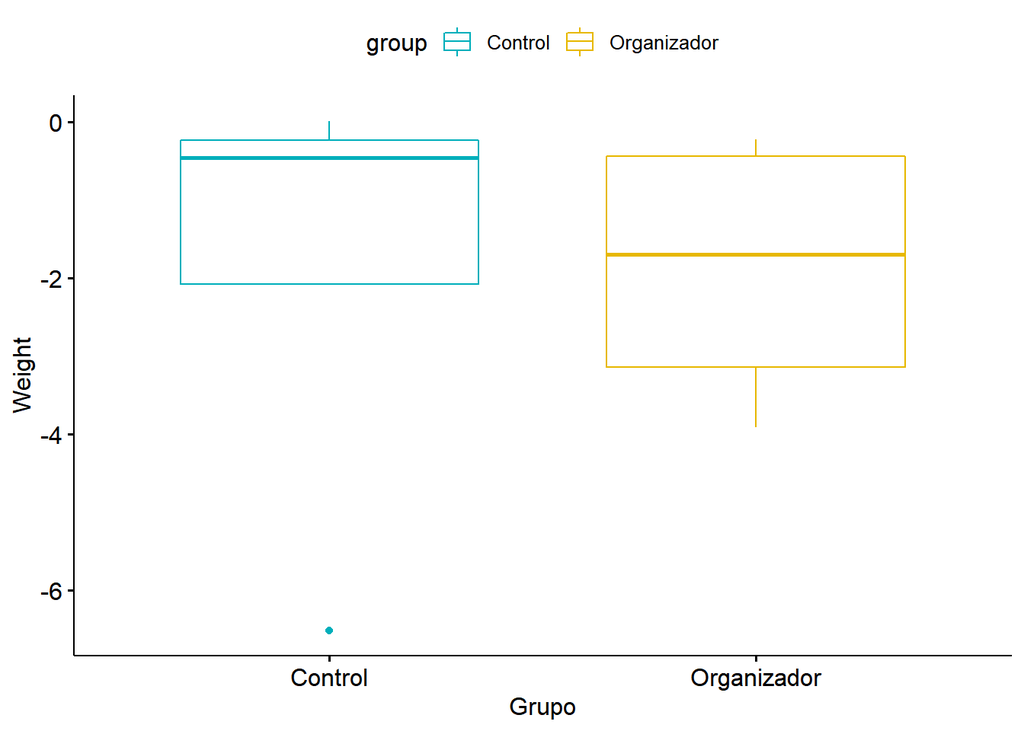

[1] “  
p-valor para dos años después 0.772829992684449” [1] “

## Acceso a la electricidad (% de poblacion)

" [1] “

### Comparación con un año antes

"

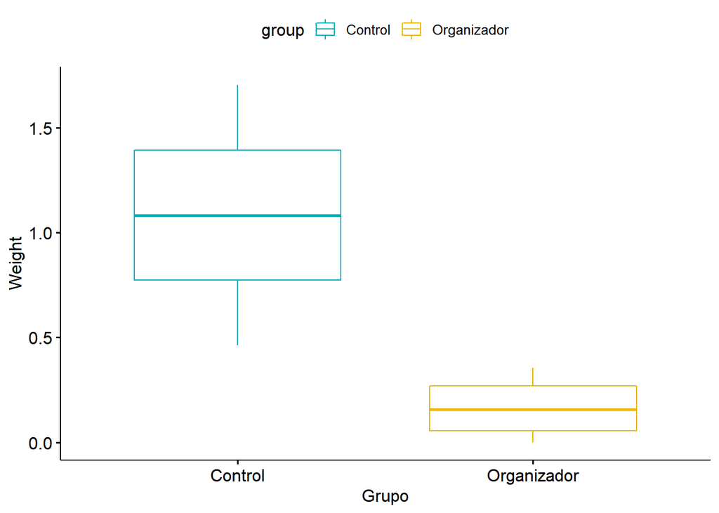

[1] “  
p-valor para un año antes 0.0640775064510595” [1] “

"

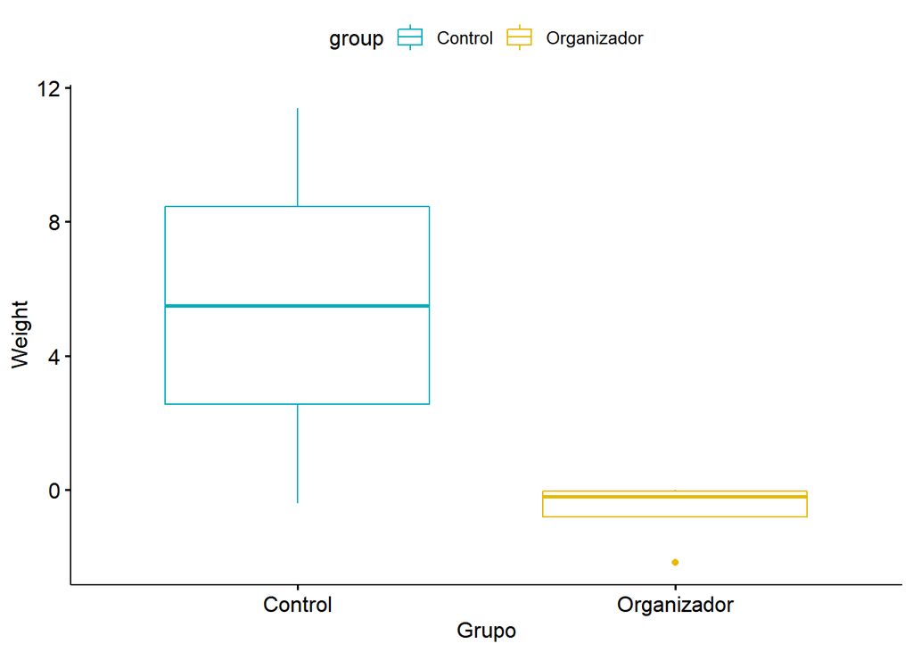

### Comparación con dos años después

"

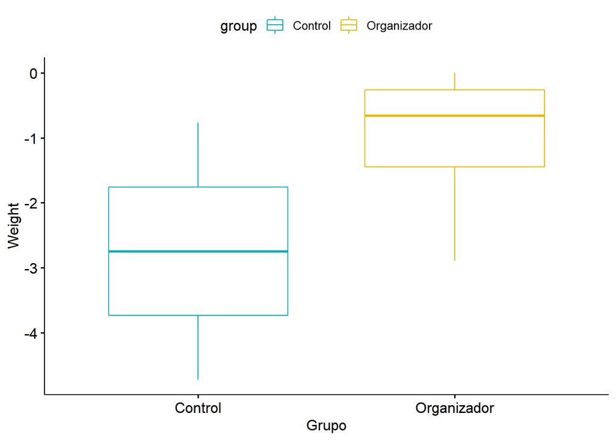

[1] “  
p-valor para dos años después 0.354539479773501” [1] “

## Consumo de energia renovable (% del consumo total de energia final)

" [1] “

### Comparación con un año antes

"

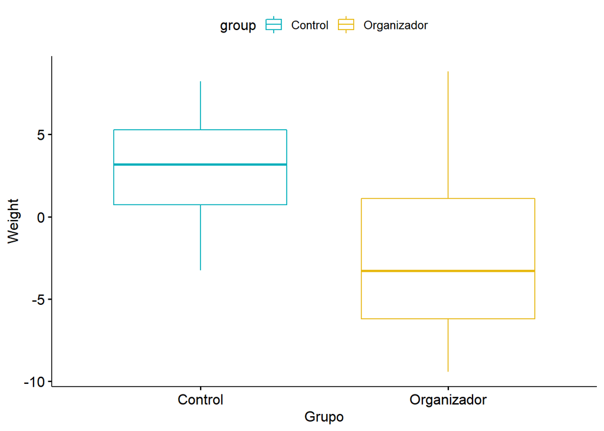

[1] “  
p-valor para un año antes 0.386476230771233” [1] “

### Comparación con un año después

"

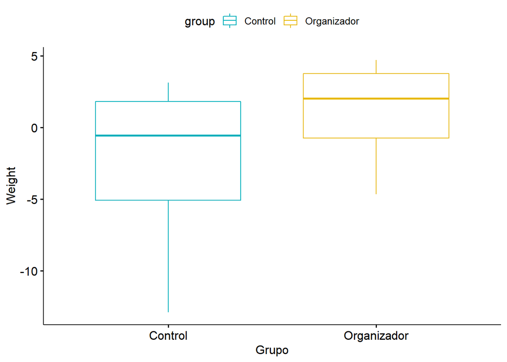

[1] “  
p-valor para un año después 0.386476230771233” [1] “

### Comparación con dos años después

"

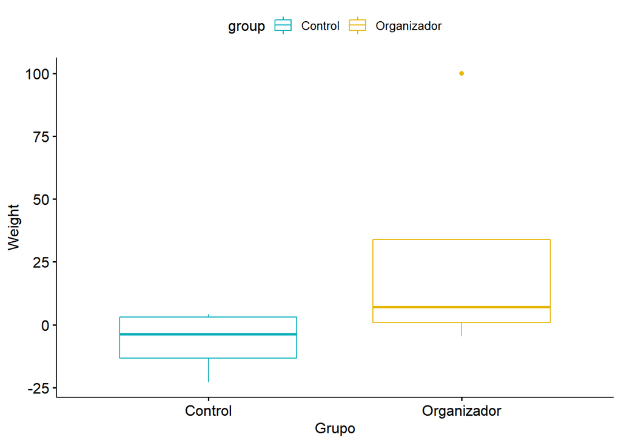

[1] “  
p-valor para dos años después 0.248213078989924” [1] “

## Gasto en investigacion y desarrollo (% del PIB)

" [1] “

### Comparación con un año antes

"

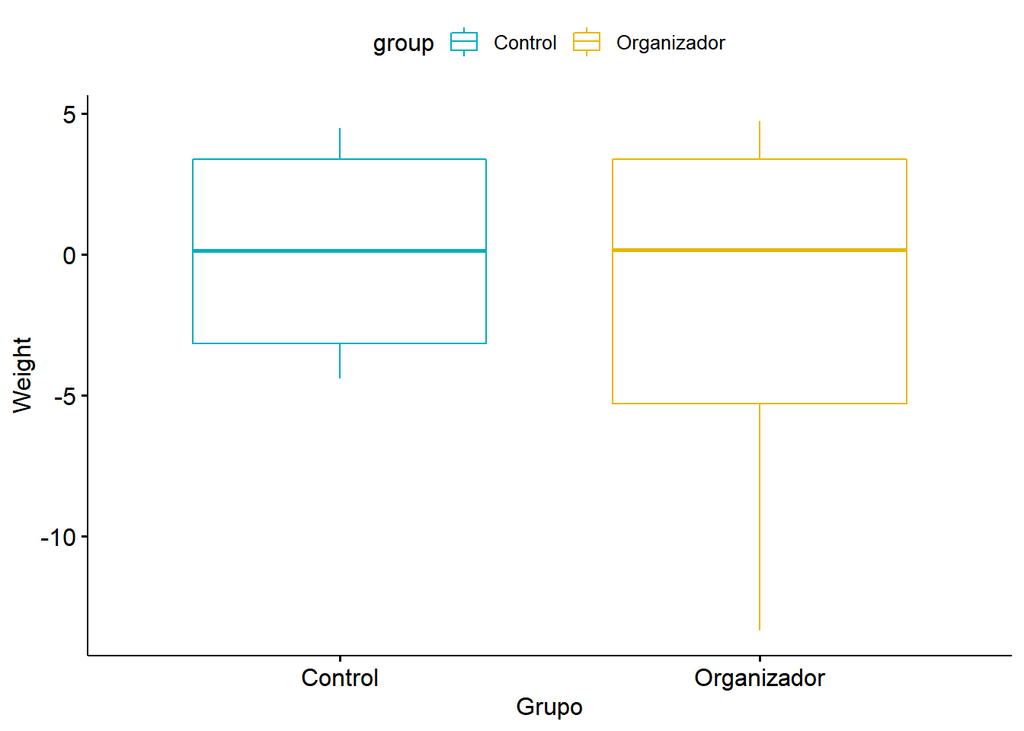

[1] “  
p-valor para un año antes 1” [1] “

### Comparación con un año después

"

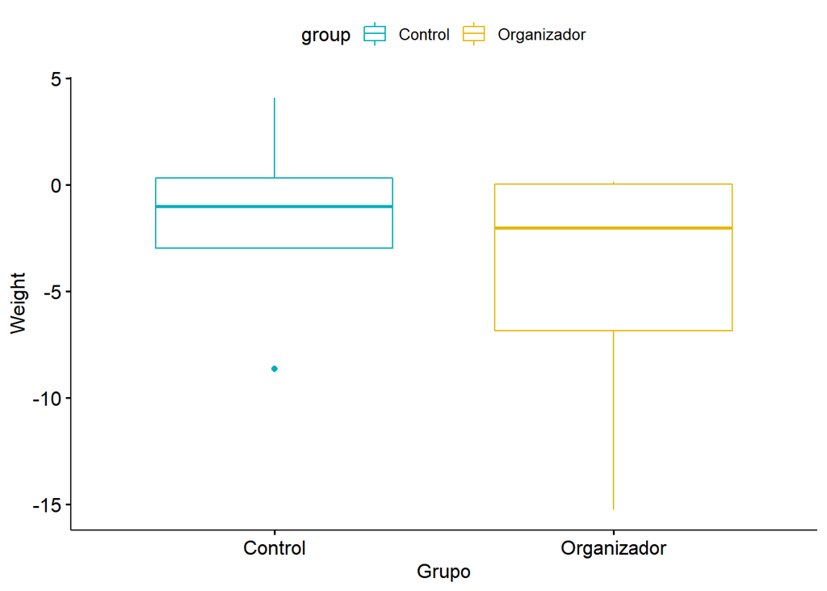

[1] “  
p-valor para un año después 0.772829992684449” [1] “

### Comparación con dos años después

"

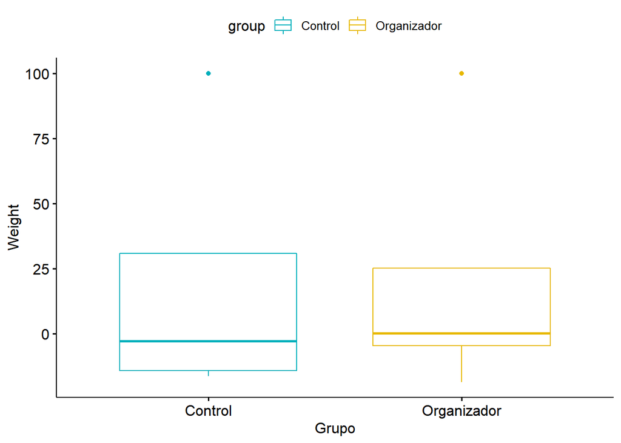

[1] “  
p-valor para dos años después 0.884549438852966” [1] “

## Suscripciones a telefonia celular movil (por cada 100Â personas)

" [1] “

### Comparación con un año antes

"

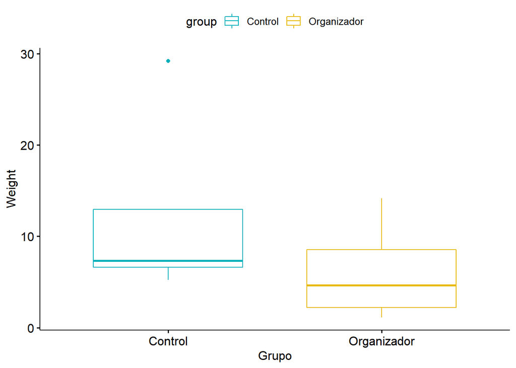

[1] “  
p-valor para un año antes 0.248213078989924” [1] “

### Comparación con un año después

"

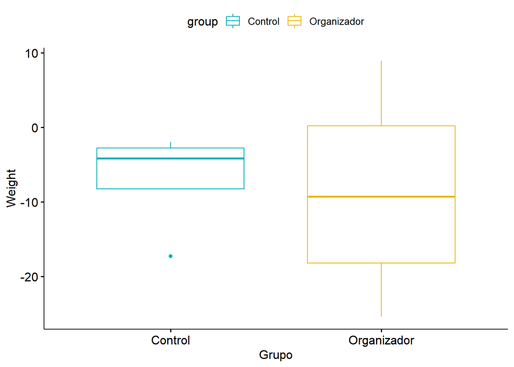

[1] “  
p-valor para un año después 1” [1] “

### Comparación con dos años después

"

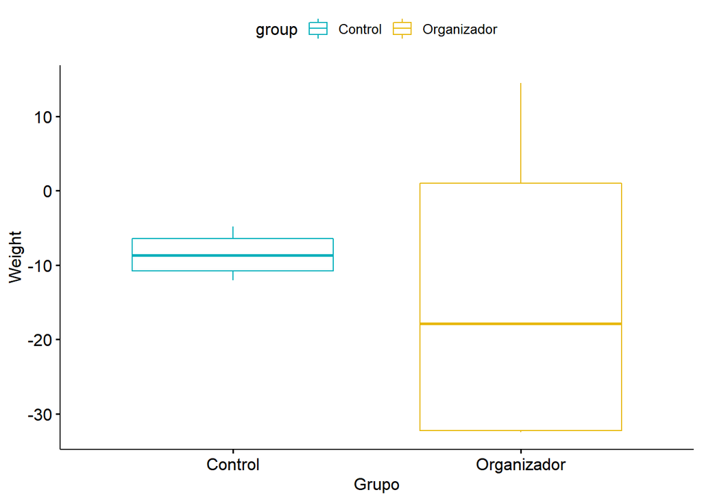

[1] “  
p-valor para dos años después 1” [1] “

## Suscripciones a banda ancha fija (por cada 100Â personas)

" [1] “

### Comparación con un año antes

"

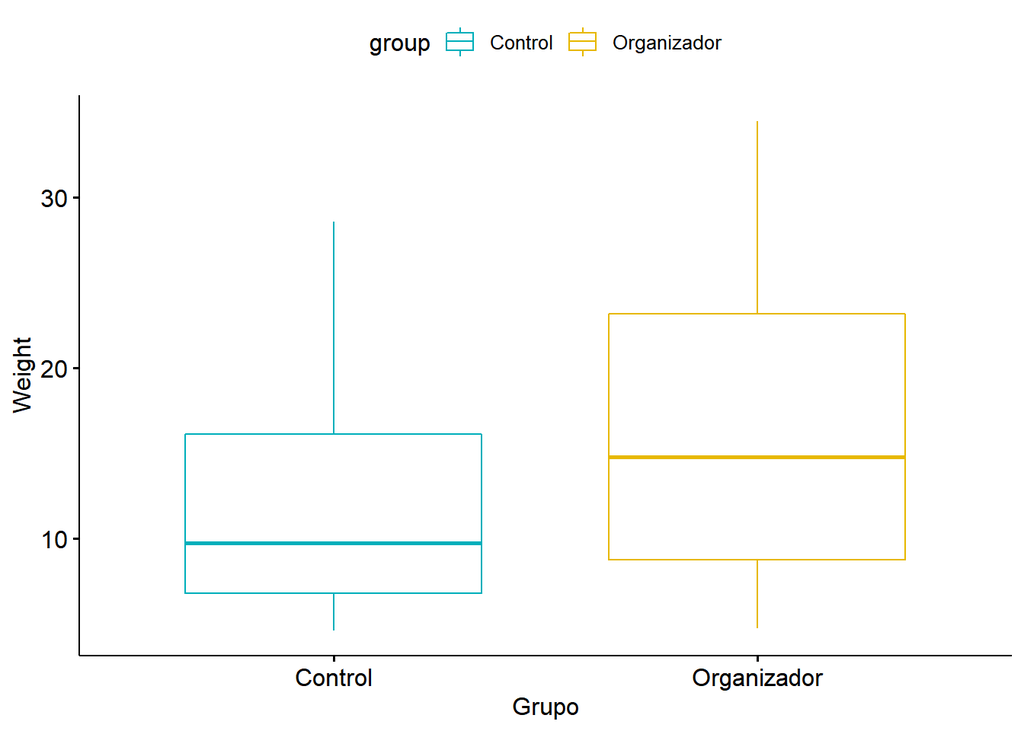

[1] “  
p-valor para un año antes 0.563702861650774” [1] “

### Comparación con un año después

"

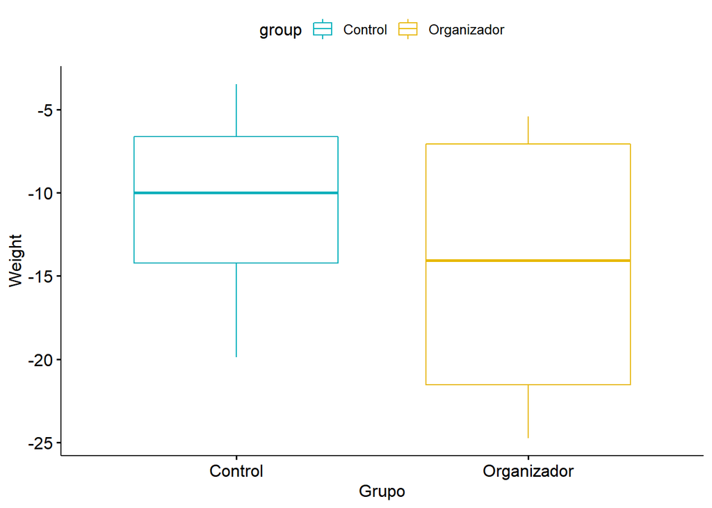

[1] “  
p-valor para un año después 0.563702861650774” [1] “

### Comparación con dos años después

"

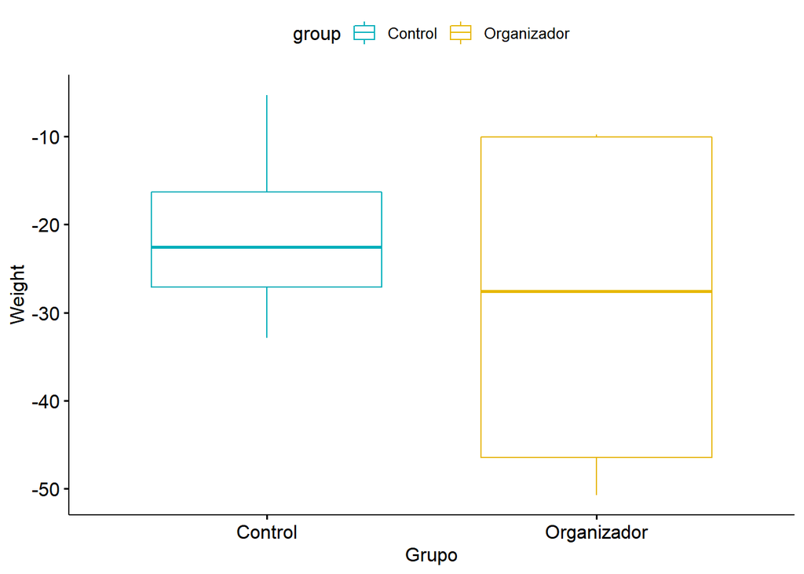

[1] “  
p-valor para dos años después 0.563702861650774” [1] “

## Personas que usan Internet (% de la poblacion)

" [1] “

### Comparación con un año antes

"

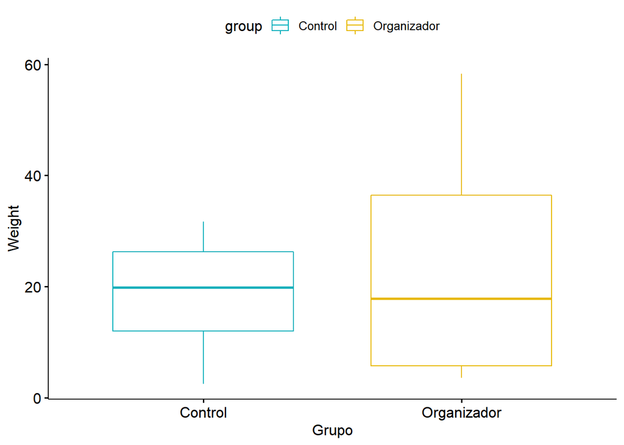

[1] “  
p-valor para un año antes 0.772829992684449” [1] “

### Comparación con un año después

"

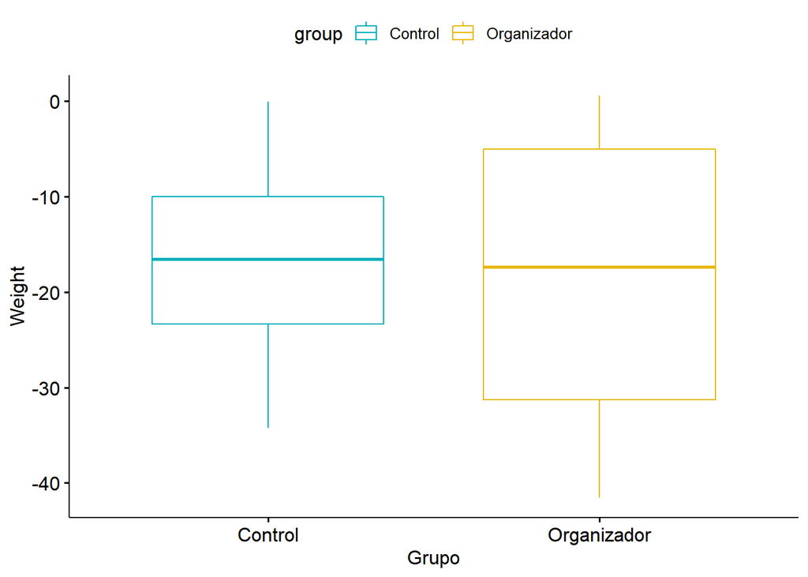

[1] “  
p-valor para un año después 1” [1] “

### Comparación con dos años después

"

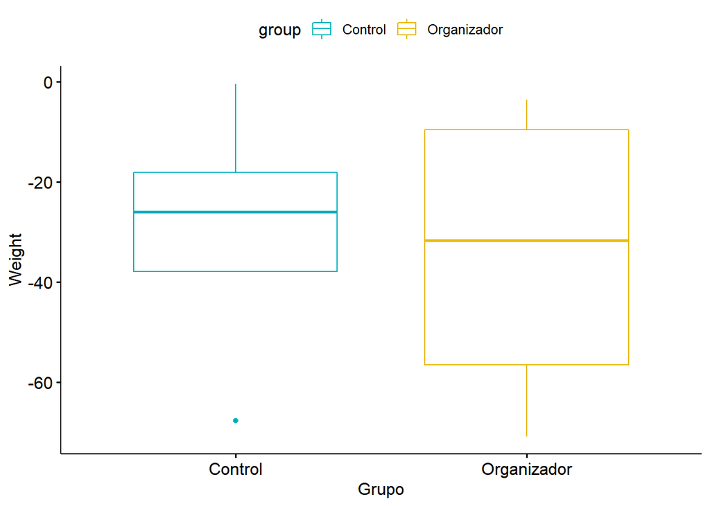

[1] “  
p-valor para dos años después 0.772829992684449” [1] “

## Gasto de consumo final de los hogares (US$ a precios actuales)

" [1] “

### Comparación con un año antes

"

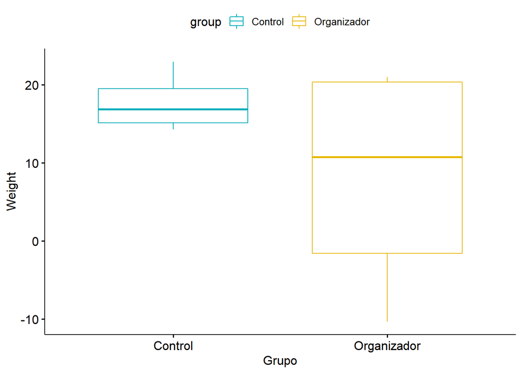

[1] “  
p-valor para un año antes 0.563702861650774” [1] “